# LAB 1 - Parte 2: Respostas Individuais

O twitter é uma rede social que oferece um espaço, atualmente, de 280 caracteres para o usuário postar sua mensagem. Também conhecido como microblogging, devido ao seu pouco espaço disponível para postagem de informação. O twitter ganha cada vez mais adeptos na internet. E com isso os usuários são capazes de expor opniões, críticas ou sentimentos em seus tweets, logo, os parlamentares brasileiros costumam utilizar a rede social para mostrar seus trabalhos, críticar outros parlamentares ou o governo, e entre outras coisas.

Com isso foram coletados alguns dados que mostram se os parlamentares da câmara e do senado possuem algum perfil no twitter,se sim, quantos seguidores possuem e como é a sua participação na rede social com tweets de próprio de contéudo e retweets.

```r
perfis_twitter = read_csv(here::here("data/atividade-por-perfil-20190322.csv"))
glimpse(perfis_twitter)
```

```
## Observations: 608
## Variables: 19
## $ id_parlamentar        <dbl> 204554, 204521, 204379, 204560, 204528, 12…
## $ casa                  <chr> "câmara", "câmara", "câmara", "câmara", "c…
## $ nome_eleitoral        <chr> "ABÍLIO SANTANA", "ABOU ANNI", "ACÁCIO FAV…
## $ partido               <chr> "PR", "PSL", "PROS", "PSDB", "NOVO", "PP",…
## $ UF                    <chr> "BA", "SP", "AP", "BA", "SP", "GO", "MG", …
## $ twitter               <chr> "AbilioSantana_", "abouannipv", "FavachoAc…
## $ seguidores            <dbl> NA, NA, NA, NA, 4652, NA, NA, NA, NA, NA, …
## $ segue                 <dbl> NA, NA, NA, NA, 315, NA, NA, NA, NA, NA, N…
## $ n_proprio             <dbl> 0, 0, 0, 0, 99, 0, 0, 0, 0, 0, 0, 0, NA, 4…
## $ n_retweet             <dbl> 0, 0, 0, 0, 9, 0, 0, 0, 0, 0, 0, 0, NA, 1,…
## $ engaj_total           <dbl> 0, 0, 0, 0, 7090, 0, 0, 0, 0, 0, 0, 0, NA,…
## $ engaj_total_proprio   <dbl> 0, 0, 0, 0, 6701, 0, 0, 0, 0, 0, 0, 0, NA,…
## $ engaj_total_retweet   <dbl> 0, 0, 0, 0, 389, 0, 0, 0, 0, 0, 0, 0, NA, …
## $ engaj_mediano         <dbl> 0.0, 0.0, 0.0, 0.0, 26.5, 0.0, 0.0, 0.0, 0…
## $ engaj_mediano_proprio <dbl> 0.0, 0.0, 0.0, 0.0, 22.5, 0.0, 0.0, 0.0, 0…
## $ engaj_mediano_retweet <dbl> 0.0, 0.0, 0.0, 0.0, 0.0, 0.0, 0.0, 0.0, 0.…
## $ engaj_max             <dbl> 0, 0, 0, 0, 1031, 0, 0, 0, 0, 0, 0, 0, NA,…
## $ engaj_max_proprio     <dbl> 0, 0, 0, 0, 1031, 0, 0, 0, 0, 0, 0, 0, NA,…
## $ engaj_max_retweet     <dbl> 0, 0, 0, 0, 99, 0, 0, 0, 0, 0, 0, 0, NA, 4…
```

Portanto, foram criadas algumas perguntas que serão respondidas a partir das visualizações abaixo.

### No estado da paraíba, PB, quais são os deputados mais ativos no twitter?

```r
deputados_twitter_pb = perfis_twitter %>%
  filter(twitter != "NA") %>%
  filter(casa == "câmara") %>%
  filter(UF == "PB") %>%
  mutate(engaj_total = as.integer(engaj_total))

glimpse(deputados_twitter_pb)
```

```
## Observations: 11
## Variables: 19
## $ id_parlamentar        <dbl> 160527, 74467, 141422, 204393, 204394, 160…
## $ casa                  <chr> "câmara", "câmara", "câmara", "câmara", "c…
## $ nome_eleitoral        <chr> "AGUINALDO RIBEIRO", "DAMIÃO FELICIANO", "…
## $ partido               <chr> "PP", "PDT", "DEM", "PT", "PSB", "PRB", "P…
## $ UF                    <chr> "PB", "PB", "PB", "PB", "PB", "PB", "PB", …
## $ twitter               <chr> "aguinaldo1111", "drdamiao", "efraimfilho"…
## $ seguidores            <dbl> NA, NA, 27351, NA, 10731, NA, NA, 5105, 14…
## $ segue                 <dbl> NA, NA, 21197, NA, 8421, NA, NA, 663, 6922…
## $ n_proprio             <dbl> 0, 0, 27, 0, 52, 0, 0, 12, 14, 0, 2
## $ n_retweet             <dbl> 0, 0, 0, 0, 49, 0, 0, 3, 0, 0, 0
## $ engaj_total           <int> 0, 0, 183, 0, 626, 0, 0, 2515, 29, 0, 10
## $ engaj_total_proprio   <dbl> 0, 0, 183, 0, 481, 0, 0, 874, 29, 0, 10
## $ engaj_total_retweet   <dbl> 0, 0, 0, 0, 145, 0, 0, 1641, 0, 0, 0
## $ engaj_mediano         <dbl> 0.0, 0.0, 5.0, 0.0, 4.0, 0.0, 0.0, 51.0, 1…
## $ engaj_mediano_proprio <dbl> 0.0, 0.0, 5.0, 0.0, 2.0, 0.0, 0.0, 47.0, 1…
## $ engaj_mediano_retweet <dbl> 0, 0, 0, 0, 0, 0, 0, 0, 0, 0, 0
## $ engaj_max             <dbl> 0, 0, 37, 0, 56, 0, 0, 1548, 5, 0, 7
## $ engaj_max_proprio     <dbl> 0, 0, 37, 0, 56, 0, 0, 354, 5, 0, 7
## $ engaj_max_retweet     <dbl> 0, 0, 0, 0, 41, 0, 0, 1548, 0, 0, 0
```

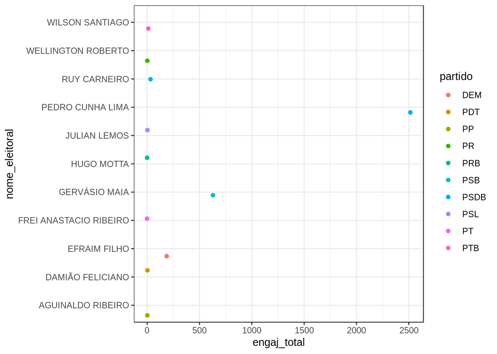

```r
deputados_twitter_pb %>%
  ggplot(mapping = aes(x = engaj_total, y = nome_eleitoral, color = partido)) +
  geom_jitter()
```

Pela visualização acima podemos ver que os deputados que possuem maior engajamento no twitter é Pedro Cunha Lima, Gervásio Maia e Efraim Filho. E todos os outros deputados são muito pouco ativos ou não possuem engajamento nenhum.

Para esses deputados que possuem algum engajamento, a participação é maior em tweets de próprio contéudo ou retweets?

```r
deputados_twitter_pb_engaj = deputados_twitter_pb %>%
  filter(engaj_total > 0)

glimpse(deputados_twitter_pb_engaj)
```

```
## Observations: 5
## Variables: 19
## $ id_parlamentar        <dbl> 141422, 204394, 178912, 160635, 74044
## $ casa                  <chr> "câmara", "câmara", "câmara", "câmara", "c…
## $ nome_eleitoral        <chr> "EFRAIM FILHO", "GERVÁSIO MAIA", "PEDRO CU…
## $ partido               <chr> "DEM", "PSB", "PSDB", "PSDB", "PTB"
## $ UF                    <chr> "PB", "PB", "PB", "PB", "PB"
## $ twitter               <chr> "efraimfilho", "gervasiomaia", "pedroocl",…
## $ seguidores            <dbl> 27351, 10731, 5105, 14086, 8340
## $ segue                 <dbl> 21197, 8421, 663, 6922, 5972
## $ n_proprio             <dbl> 27, 52, 12, 14, 2
## $ n_retweet             <dbl> 0, 49, 3, 0, 0
## $ engaj_total           <int> 183, 626, 2515, 29, 10
## $ engaj_total_proprio   <dbl> 183, 481, 874, 29, 10
## $ engaj_total_retweet   <dbl> 0, 145, 1641, 0, 0
## $ engaj_mediano         <dbl> 5.0, 4.0, 51.0, 1.5, 5.0
## $ engaj_mediano_proprio <dbl> 5.0, 2.0, 47.0, 1.5, 5.0
## $ engaj_mediano_retweet <dbl> 0, 0, 0, 0, 0
## $ engaj_max             <dbl> 37, 56, 1548, 5, 7
## $ engaj_max_proprio     <dbl> 37, 56, 354, 5, 7
## $ engaj_max_retweet     <dbl> 0, 41, 1548, 0, 0
```

### Engajamento em tweets de próprio contéudo…

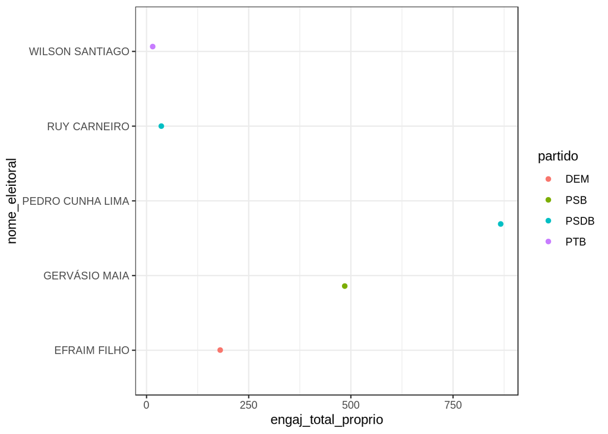

```r
deputados_twitter_pb_engaj %>%
  ggplot(mapping = aes(x = engaj_total_proprio, y = nome_eleitoral, color = partido)) +
  geom_jitter()
```

Dentre de todos esses deputados, Pedro Cunha Lima é o que mais possui tweets de próprio de conteúdo juntamente com o deputado Gervásio Maia.

### Engajamento em retweets…

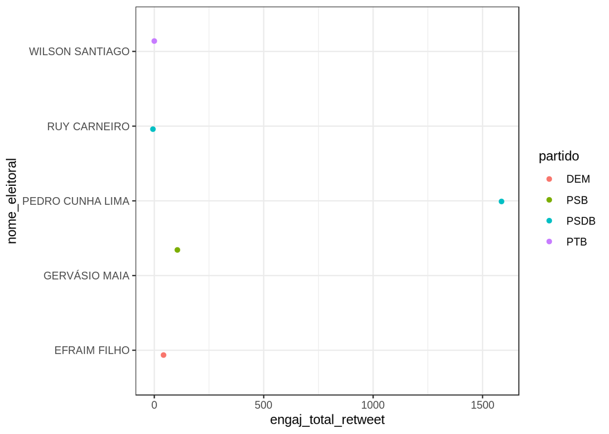

```r
deputados_twitter_pb_engaj %>%
  ggplot(mapping = aes(x = engaj_total_retweet, y = nome_eleitoral, color = partido)) +
  geom_jitter()
```

Além disso, os dois parlamentares, Pedro Cunha Lima e Gervásio Maia, possuem um grande engajamento em retweets.

Mas, olhando para a escala do eixo x nas duas visualizações, temos que o engajamento do deputado Pedro Cunha Lima é maior em retweets, e os demais parlamentares, possuem mais tweets de conteúdo próprio do que retweets.

### Os deputados que são filiados ao PSL são ativos no twitter assim como o atual presidente da república?

```r
camara_psl = perfis_twitter %>%
    filter(casa == "câmara") %>%
  filter(partido == "PSL") %>%
  filter(twitter != "NA") %>%
  mutate(engaj_total = as.integer(engaj_total))

glimpse(camara_psl)
```

```
## Observations: 44
## Variables: 19
## $ id_parlamentar        <dbl> 204521, 204545, 204544, 204374, 204388, 20…
## $ casa                  <chr> "câmara", "câmara", "câmara", "câmara", "c…
## $ nome_eleitoral        <chr> "ABOU ANNI", "ALÊ SILVA", "ALEXANDRE FROTA…
## $ partido               <chr> "PSL", "PSL", "PSL", "PSL", "PSL", "PSL", …
## $ UF                    <chr> "SP", "MG", "SP", "DF", "RS", "MG", "SP", …
## $ twitter               <chr> "abouannipv", "oficialalesilva", "alefrota…
## $ seguidores            <dbl> NA, 464, 161745, 81544, NA, 7575, 103029, …
## $ segue                 <dbl> NA, 267, 2015, 742, NA, 63, 156, 907, 91, …
## $ n_proprio             <dbl> 0, 39, 830, 368, 0, 38, 776, 533, 13, 44, …
## $ n_retweet             <dbl> 0, 4, 169, 625, 0, 3, 223, 134, 4, 3, 0, 2…
## $ engaj_total           <int> 0, 10231, 566011, 1893839, 0, 46227, 33101…
## $ engaj_total_proprio   <dbl> 0, 186, 320063, 717602, 0, 21803, 2822907,…
## $ engaj_total_retweet   <dbl> 0, 10045, 245948, 1176237, 0, 24424, 48723…
## $ engaj_mediano         <dbl> 0.0, 4.0, 134.0, 773.0, 0.0, 243.0, 848.0,…
## $ engaj_mediano_proprio <dbl> 0, 4, 60, 0, 0, 182, 88, 65, 103, 2, 0, 10…
## $ engaj_mediano_retweet <dbl> 0, 0, 0, 202, 0, 0, 0, 0, 0, 0, 0, 0, 0, 0…
## $ engaj_max             <dbl> 0, 8171, 20348, 52614, 0, 19559, 33584, 19…
## $ engaj_max_proprio     <dbl> 0, 14, 7271, 27501, 0, 9516, 33584, 13034,…
## $ engaj_max_retweet     <dbl> 0, 8171, 20348, 52614, 0, 19559, 28088, 19…
```

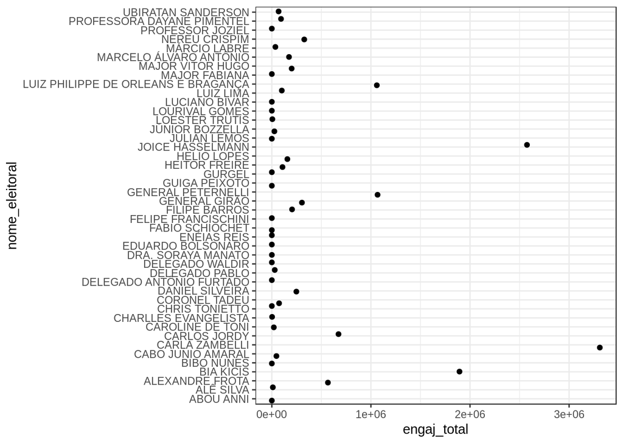

```r
camara_psl %>%
  ggplot(mapping = aes(x = engaj_total, y = nome_eleitoral)) +
  geom_jitter()
```

Podemos ver que boa parte dos deputados do PSL possuem eganjamento com valores bem próximos a 0, além disso, os 3 deputados que são mais ativos são: Bia Kicis, Carla Zambelli e Joice Hasselmann. Existem alguns parlamentares, tais como Luiz Phillippe de Orlenas e Bragança, General Peternelli, Carlos Jordy e Alexandre Frota que também são bem mais ativos que os demais.

### E quais destes parlamentares são mais ativos em retweets?

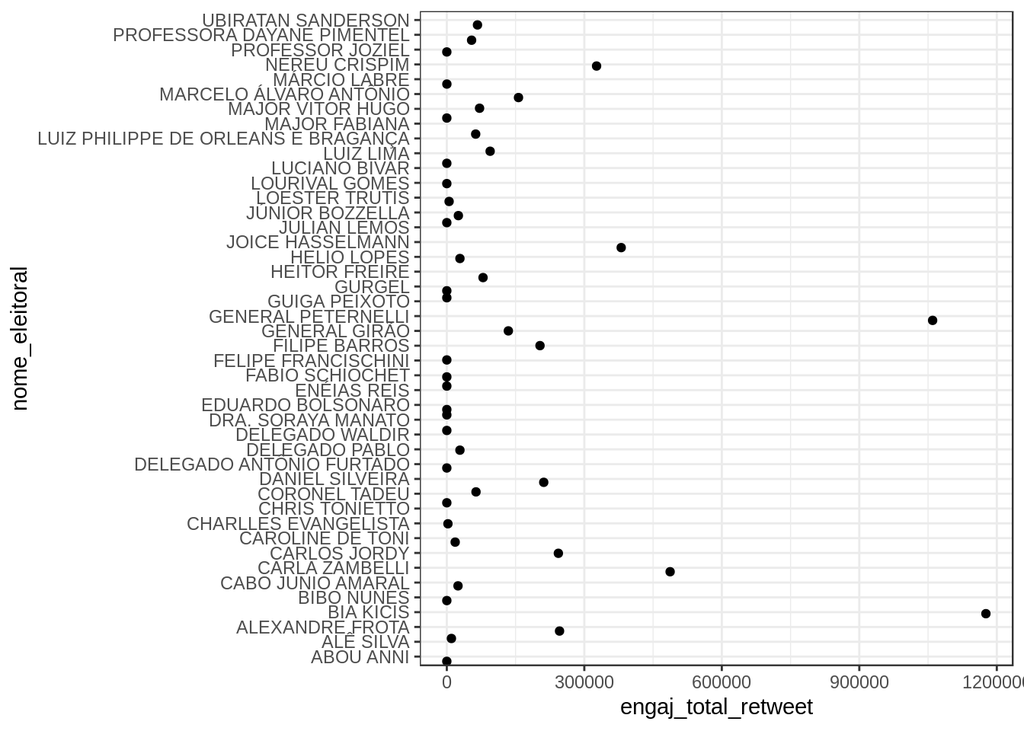

```r
camara_psl %>%
  ggplot(mapping = aes(x = engaj_total_retweet, y = nome_eleitoral)) +
  geom_jitter()
```

### E quais destes parlamentares são mais ativos em tweets de próprio contéudo?

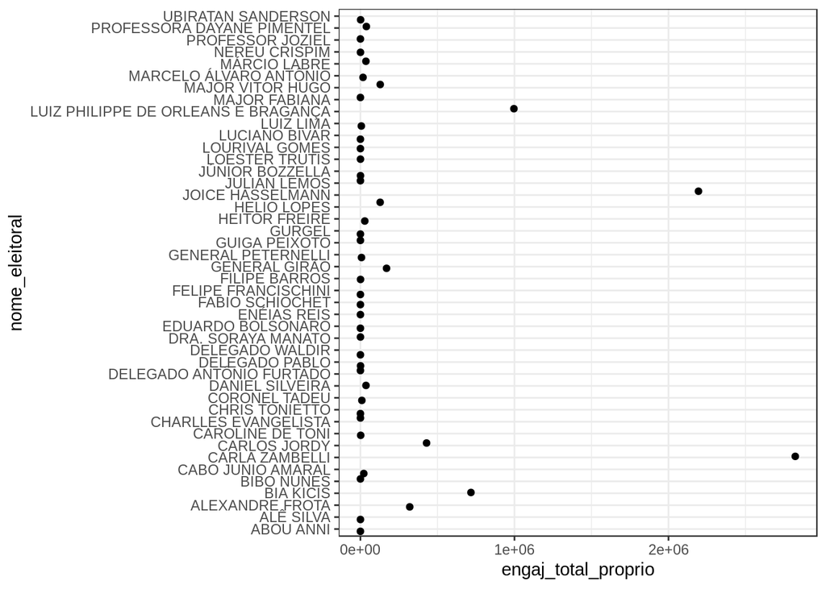

```r
camara_psl %>%
  ggplot(mapping = aes(x = engaj_total_proprio, y = nome_eleitoral)) +
  geom_jitter()
```

A maioria dos deputados estão em uma faixa de valores, porém existem alguns que estão fora deste intervalo, como: Alexandre Frota, Bia Kicis, Carla Zambelli, Carlos Jordy, Joice Hasselmann e Luiz Philippe de Orleans e Brangança.